# Module 5: Continuous Phenotyping with Φ-Space

Single Cell Workshop

2026-04-23

## 1 Introduction

In Module 3 we annotated cell types by looking up **marker genes** and assigning each cluster a single discrete label. That approach is intuitive and directly interpretable, but it rests on two assumptions that are not always true for the heart maturation dataset we are analysing:

1. **Cells belong to one cell type.** A cluster is given a single label, and every cell inside it inherits that label.
2. **Cell identity is discrete.** Cells are either cardiomyocytes or they are not; there is no notion of a cell that is *partly* a fetal cardiomyocyte and *partly* an adult one.

For a mature tissue with well-separated cell types, these assumptions are reasonable. But our dataset spans foetal, young and adult heart samples, so many cells — especially cardiomyocytes — are in the middle of a maturation continuum. A discrete label forces each cell into one bin and throws away the very gradient we want to study in Module 6 (pseudotime) and Module 7 (gene regulatory networks).

In this module we use **Φ-Space** ([Mao, Deng & Lê Cao, 2025, *Genome Biology*](https://doi.org/10.1186/s13059-025-03755-8)) to re-annotate the heart data with *continuous* phenotype scores instead of hard labels.

### 1.1 From hard labels to soft scores

The core idea of Φ-Space is simple: instead of asking *“which cell type is this cell?”*, ask *“how much does this cell resemble each reference phenotype?”*. For every query cell and every phenotype in the reference atlas, Φ-Space returns a real-valued score. A cell that sits halfway between “foetal cardiomyocyte” and “adult cardiomyocyte” will score positively on both; a cell committed firmly to one identity will score high on one and low on the other.

Under the hood, Φ-Space fits a **partial least squares (PLS)** regression from gene expression in the reference onto a dummy matrix of phenotype labels. The fitted model is then applied to the query, producing one score per cell per phenotype. This matrix of scores — the **phenotype space embedding** — is stored as a `reducedDim` and becomes the substrate for every downstream analysis: visualisation, clustering, marker selection, and trajectory inference.

### 1.2 Why Φ-Space is a good fit for this dataset

Five features of Φ-Space line up unusually well with the Sim et al. heart data:

1. **Continuous biology deserves continuous annotation.** Cardiomyocyte maturation is gradual. Φ-Space preserves the gradient; hard classification collapses it.
2. **Multiple phenotype layers at once.** We can score each cell simultaneously against cell type *and* developmental stage. Most tools predict one label at a time.
3. **Bulk references are allowed.** There is no single cross-age snRNA-seq atlas of the human heart that covers fetal through adult equally well. Φ-Space also accepts bulk RNA-seq references, which opens up developmental bulk time-course atlases as viable options.
4. **No extra batch correction between reference and query.** PLS inherently removes unwanted variation. You do not need to run Harmony *between* query and reference — only to match normalisation.
5. **The embedding feeds directly into Modules 6 and 7.** Because scores are stored in `reducedDim`, they can be used as input for slingshot (pseudotime) and NeighbourNet (gene regulatory networks) without any extra wrangling.

### 1.3 Learning objectives

By the end of this module you will be able to:

- Explain the difference between hard and soft classification for cell type annotation, and identify situations where each is appropriate.
- Prepare an annotated reference dataset and a query dataset for Φ-Space, including matched normalisation and gene name harmonisation.
- Run `PhiSpace()` to obtain a continuous phenotype space embedding for the query cells.
- Visualise and interpret the phenotype space embedding through heatmaps and a PCA biplot.
- Derive discrete labels from continuous scores when needed, and understand what is gained and lost in that step.
- Export the phenotype space embedding in a form that Modules 6 and 7 can consume.

## 2 Load Libraries and Data

```r
library(PhiSpace)
library(SingleCellExperiment)
library(Seurat)
library(ggplot2)
library(dplyr)
library(tibble)
library(patchwork)
library(ComplexHeatmap)
```

We need two data objects:

- a **query** — the heart snRNA-seq data from the morning session, trimmed to the essentials (raw counts, sample / stage / sex metadata, ~10,000 cells).
- a **reference** — an annotated left-ventricle atlas covering the full developmental axis (see the next section for details).

```r
seu <- readRDS("../data/afternoon_mvp.rds")
reference <- readRDS("../data/reference_gao2026.rds")

cat("Query (Seurat):\n")
```

```
## Query (Seurat):
```

```r
cat("  - cells:", ncol(seu), "\n")
```

```
##   - cells: 10000
```

```r
cat("  - genes:", nrow(seu), "\n")
```

```
##   - genes: 18953
```

```r
cat("  - metadata:", paste(colnames(seu@meta.data), collapse = ", "), "\n\n")
```

```
##   - metadata: orig.ident, nCount_RNA, nFeature_RNA, sample, group, sex, percent.mt, percent.ribo
```

```r
cat("Reference (SingleCellExperiment):\n")
```

```
## Reference (SingleCellExperiment):
```

```r
cat("  - cells:", ncol(reference), "\n")
```

```
##   - cells: 6096
```

```r
cat("  - genes:", nrow(reference), "\n")
```

```
##   - genes: 16115
```

```r
cat("  - assays:", paste(assayNames(reference), collapse = ", "), "\n")
```

```
##   - assays: logcounts
```

```r
cat("  - cell types:", length(unique(reference$final_cell_type)), "\n")
```

```
##   - cell types: 13
```

```r
cat("  - age groups:", paste(unique(reference$age_group), collapse = ", "), "\n")
```

```
##   - age groups: young, middle, old, fetal
```

Φ-Space works with `SingleCellExperiment` (SCE) objects, so we convert the query from Seurat to SCE. The raw counts travel across as the `counts` assay; the cell-level metadata travels across as `colData`.

```r
query <- as.SingleCellExperiment(seu)
assayNames(query)
```

```
## [1] "counts"
```

```r
head(colData(query)[, c("sample", "group", "sex")])
```

```
## DataFrame with 6 rows and 3 columns
##                          sample       group         sex
##                     <character> <character> <character>
## AAACCCAAGTTTCGAC_f1          f1       fetal           m
## AAACCCACAAATGAGT_f1          f1       fetal           m
## AAACGAACAAACTCTG_f1          f1       fetal           m
## AAACGAACAGCGGTTC_f1          f1       fetal           m
## AAACGAATCCGATAAC_f1          f1       fetal           m
## AAAGAACGTCATACCA_f1          f1       fetal           m
```

We will also set up a cache folder for intermediate results. Computations that take more than a few seconds are cached to `../results/` so that re-rendering this vignette is fast, and so that workshop participants can download the pre-computed caches directly if they prefer.

```r
results_dir <- "../results"
dir.create(results_dir, showWarnings = FALSE, recursive = TRUE)
```

## 3 Choosing a Reference Dataset

A Φ-Space annotation is only as good as the reference it is built on. For the Sim et al. heart data we need a reference that:

- **covers the full developmental axis** — foetal, paediatric and adult heart, so that every query cell has something biologically sensible to score against;
- **annotates cell types at a useful granularity** — at least the major heart lineages (cardiomyocyte, fibroblast, endothelial, pericyte, immune, epicardial, neuronal);
- **is publicly available** and free of major disease confounders.

We use the **Gao et al. 2026** (*Genome Biology*) integrative snRNA-seq atlas of the human left ventricle. It combines 299 donors from eight published studies, spans 8 post-conceptional weeks through ≥60 years, and provides harmonised cell type and age-group annotations. We have pre-filtered it to non-diseased donors and balanced the major cell types by down-sampling; the processing script lives at `references/prepare_gao_2026.R`.

Two columns from the reference drive everything that follows:

```r
table(reference$final_cell_type)
```

```
##
##     Adipocyte Cardiomyocyte   Endocardial   Endothelial    Epicardial
##           100          1899           119           563           100
##    Fibroblast           LEC      Lymphoid          Mast       Myeloid
##          1327           100           176           100           678
##      Neuronal      Pericyte          vSMC
##           100           717           117
```

```r
table(reference$age_group)
```

```
##
##  fetal middle    old  young
##    140   2865   2038   1053
```

Notice the reference’s `age_group` is `fetal / young / middle / old`, while our query’s `group` is `fetal / young / adult`. That is fine — Φ-Space will score each query cell against all four reference age groups, and we will use those four scores as a fine-grained read-out of where on the maturation axis each cell sits.

### 3.1 Zooming in: splitting cardiomyocyte and fibroblast into subtypes

Looking at `final_cell_type` above, **Cardiomyocyte** (~1,900 cells) and **Fibroblast** (~1,300 cells) dominate the reference. They are also the two lineages we care about most biologically: cardiomyocytes carry the foetal→adult maturation signal we will trace in Module 6, and fibroblasts reshape the extracellular matrix across development. The Gao 2026 authors further annotated these two lineages into biologically meaningful subclusters (e.g. `Fetal_enriched_metabolic`, `Stressed`, `Interstitial`, `Perivascular` …) — stored in the `cell_type_plus_subcluster` column as `CellType:Subtype` strings.

We therefore build a **fine cell-type column** that keeps every non-CM, non-Fibroblast cell on its broad label, and replaces the CM / Fibroblast labels with the Gao subclusters. Two things happen at once:

1. **We zoom in on the cells we care about.** When a small number of cell types carry most of the biological signal, it is worth asking Φ-Space to resolve them more finely. Every CM subcluster becomes its own phenotype column in the score matrix, so we can tell a `Fetal_enriched_metabolic` CM from a `Stressed` CM rather than collapsing both into “Cardiomyocyte”.
2. **The reference becomes more balanced.** Splitting the two giant classes into ~8 + ~7 smaller classes brings their per-class counts closer to the rarer lineages (Pericyte, Myeloid, Endothelial, …). PLS over-fits the majority class when the reference is unbalanced, and this split softens that skew for free.

```r
ct <- reference$final_cell_type
sub <- reference$cell_type_plus_subcluster
# Replace only the two populous lineages with their subclusters;
# leave the rest on their broad label.
reference$cell_type_fine <- ifelse(
    ct %in% c("Cardiomyocyte", "Fibroblast"),
    sub,
    ct
)

sort(table(reference$cell_type_fine), decreasing = TRUE)
```

```
##
##                                Pericyte                                 Myeloid
##                                     717                                     678
##                     Cardiomyocyte:Other                  Fibroblast:ND_enriched
##                                     605                                     567
##                             Endothelial                 Cardiomyocyte:Metabolic
##                                     563                                     406
##  Cardiomyocyte:Fetal_enriched_metabolic                 Fibroblast:Interstitial
##                                     332                                     229
##             Fibroblast:DCM_HCM_enriched                  Cardiomyocyte:Stressed
##                                     205                                     180
##                                Lymphoid Cardiomyocyte:Fetal_enriched_conduction
##                                     176                                     174
##          Cardiomyocyte:DCM_HCM_enriched                             Endocardial
##                                     156                                     119
##                                    vSMC                Fibroblast:Anti_fibrotic
##                                     117                                     116
##                 Fibroblast:Perivascular                               Adipocyte
##                                     114                                     100
##                              Epicardial                                     LEC
##                                     100                                     100
##                                    Mast                                Neuronal
##                                     100                                     100
##                    Fibroblast:Activated              Cardiomyocyte:Inflammatory
##                                      90                                      42
##                 Fibroblast:Inflammatory                 Cardiomyocyte:Senescent
##                                       6                                       4
```

Note the alternative we did **not** take: **balanced subsampling**. Instead of splitting the majority classes, you could down-sample them with `PhiSpace::subsample(..., key = "final_cell_type", minCellNum = ...)` so every cell type contributes a comparable number of reference cells. That is the right move when you are happy with the broad-class annotation and simply want fairer PLS training; here we chose to split instead because the CM / Fibroblast subclusters are interesting in their own right. The two approaches can also be combined — split first, then subsample within each fine label.

### 3.2 A note on very rare phenotypes

Even after splitting, some fine labels are tiny (e.g. `Cardiomyocyte:Senescent` ≈ 4 cells, `Fibroblast:Inflammatory` ≈ 6 cells). Training PLS with a phenotype represented by a handful of cells is a bad bargain: the column it produces in the score matrix is mostly noise, and it still consumes a component in the PLS fit.

`PhiSpace()` exposes a `cellTypeThreshold` argument for exactly this case — set it to, say, `20`, and any phenotype level with fewer than 20 reference cells is dropped before model fitting. We use it below to prune the long tail of the subtype split while keeping every lineage that is biologically well-represented.

## 4 Preparing Reference and Query

Three preparation steps are required before we can run Φ-Space:

1. **Match normalisation.** Φ-Space does not do batch correction between reference and query; it relies on both being on the same numerical scale.
2. **Match gene names.** PLS can only use genes present in both datasets.
3. **Quality control.** Remove all-zero genes from the query, which would otherwise carry no signal but still consume model capacity.

### 4.1 Match normalisation with scran

The reference is stored with a `logcounts` assay (scran-normalised during reference preparation — see `HPC_reference_processing.md`); the query carries raw `counts`. To put both on the same numerical scale we apply **scran normalisation** to the query as well, via PhiSpace’s `scranTransf()` wrapper. `scranTransf()` computes pool-based size factors with `scran::computeSumFactors()` and then calls `scuttle::logNormCounts()`, storing the result in a `logcounts` assay — the same assay name and the same normalisation family the reference already uses.

An earlier draft of this module used rank transformation instead. Rank is fast and invariant to library size, which is attractive when reference and query come from very different platforms. But for this dataset both sides are snRNA-seq, so the cross-platform argument is weaker, and scran’s size-factor normalisation preserves more of the count-level variation that PLS can exploit. The trade-off is that scran is slower, so we cache the intermediate object.

```r
ref_cache   <- file.path(results_dir, "05_reference_scran.rds")
query_cache <- file.path(results_dir, "05_query_scran.rds")

if (file.exists(ref_cache)) {
    reference <- readRDS(ref_cache)
    message("Loaded cached scran-normalised reference from ", ref_cache)
} else {
    # Reference logcounts is already scran-normalised from the HPC prep
    # script — nothing to recompute, just cache for reproducibility.
    saveRDS(reference, ref_cache)
}

if (file.exists(query_cache)) {
    query <- readRDS(query_cache)
    message("Loaded cached scran-normalised query from ", query_cache)
} else {
    query <- scranTransf(query)
    saveRDS(query, query_cache)
}

assayNames(reference)
```

```
## [1] "logcounts"
```

```r
assayNames(query)
```

```
## [1] "counts"    "logcounts"
```

Both objects now carry a `logcounts` assay, and that is what Φ-Space will use below (`refAssay = "logcounts"`).

### 4.2 Keep common genes and remove zero-expression genes

```r
common <- intersect(rownames(reference), rownames(query))
cat("Reference genes:", nrow(reference), "\n")
```

```
## Reference genes: 16115
```

```r
cat("Query genes:    ", nrow(query), "\n")
```

```
## Query genes:     18953
```

```r
cat("Common:         ", length(common), "\n")
```

```
## Common:          15100
```

```r
reference <- reference[common, ]
query     <- query[common, ]
query     <- zeroFeatQC(query)
```

```
## Deleted features with all zeros.
```

```r
dim(query)
```

```
## [1] 15094 10000
```

The gene-symbol overlap is comfortably above ten thousand, which is plenty for PLS.

### 4.3 Balancing the reference — a recap

Two levers keep the reference balanced: **splitting** dense majority classes into biologically meaningful subclusters (what we did above with CM and Fibroblast), and **subsampling** with `PhiSpace::subsample(key = ...)` to cap the per-class cell count. The Gao 2026 reference was already down-sampled during preparation (see `HPC_reference_processing.md`), capping rare types at ~100 and abundant types at a few thousand — so between that and our fine split, we are in a reasonable spot without further action.

## 5 Running Φ-Space

We now fit the PLS model on the reference and project the query into the phenotype space. We ask for two phenotype layers at once:

- `cell_type_fine` — the split label we built above (CM / Fibroblast replaced by their Gao subclusters, everything else on its broad label).
- `age_group` (4 levels) — where on the maturation axis does it sit?

We also pass `cellTypeThreshold = 20` so that phenotype levels represented by fewer than 20 reference cells are dropped before PLS fitting — this trims the long tail of rare CM / Fibroblast subclusters without touching the well-populated ones.

This step is the computational bottleneck of the module (roughly one minute on a laptop), so we cache the output.

```r
phispace_cache <- file.path(results_dir, "05_phispace_query.rds")

if (file.exists(phispace_cache)) {
    query <- readRDS(phispace_cache)
    message("Loaded cached PhiSpace result from ", phispace_cache)
} else {
    query <- PhiSpace(
        reference         = reference,
        query             = query,
        phenotypes        = c("cell_type_fine", "age_group"),
        refAssay          = "logcounts",
        regMethod         = "PLS",
        center            = TRUE,
        scale             = FALSE,
        cellTypeThreshold = 20
    )
    # Keep logcounts in the cache — Module 6 needs it for PCA on the
    # expression side of its pseudotime comparison.
    saveRDS(query, phispace_cache)
}
```

The phenotype-space embedding is stored as a `reducedDim`:

```r
phi_scores <- reducedDim(query, "PhiSpace")
dim(phi_scores)
```

```
## [1] 10000    28
```

```r
colnames(phi_scores)
```

```
##  [1] "Cardiomyocyte:Other"
##  [2] "Cardiomyocyte:Fetal_enriched_metabolic"
##  [3] "Cardiomyocyte:DCM_HCM_enriched"
##  [4] "Cardiomyocyte:Metabolic"
##  [5] "Cardiomyocyte:Stressed"
##  [6] "Cardiomyocyte:Inflammatory"
##  [7] "Cardiomyocyte:Fetal_enriched_conduction"
##  [8] "Fibroblast:Activated"
##  [9] "Fibroblast:ND_enriched"
## [10] "Fibroblast:Perivascular"
## [11] "Fibroblast:Anti_fibrotic"
## [12] "Fibroblast:Interstitial"
## [13] "Fibroblast:DCM_HCM_enriched"
## [14] "Pericyte"
## [15] "Myeloid"
## [16] "Endothelial"
## [17] "Lymphoid"
## [18] "Endocardial"
## [19] "vSMC"
## [20] "Neuronal"
## [21] "Adipocyte"
## [22] "Mast"
## [23] "LEC"
## [24] "Epicardial"
## [25] "young"
## [26] "middle"
## [27] "old"
## [28] "fetal"
```

```r
round(phi_scores[1:4, 1:6], 3)
```

```
##                     Cardiomyocyte:Other Cardiomyocyte:Fetal_enriched_metabolic
## AAACCCAAGTTTCGAC_f1              -0.349                                 -0.190
## AAACCCACAAATGAGT_f1              -0.470                                 -0.024
## AAACGAACAAACTCTG_f1               0.136                                  0.451
## AAACGAACAGCGGTTC_f1              -0.385                                 -0.244
##                     Cardiomyocyte:DCM_HCM_enriched Cardiomyocyte:Metabolic
## AAACCCAAGTTTCGAC_f1                         -0.013                  -0.007
## AAACCCACAAATGAGT_f1                          0.055                  -0.068
## AAACGAACAAACTCTG_f1                         -0.307                   0.251
## AAACGAACAGCGGTTC_f1                          0.019                   0.015
##                     Cardiomyocyte:Stressed Cardiomyocyte:Inflammatory
## AAACCCAAGTTTCGAC_f1                  0.085                      0.133
## AAACCCACAAATGAGT_f1                  0.136                      0.364
## AAACGAACAAACTCTG_f1                 -0.004                     -0.037
## AAACGAACAGCGGTTC_f1                  0.123                      0.102
```

Each row is a query cell, each column is a reference phenotype level. Values are column-wise normalised so that the median of each column is zero and the maximum absolute deviation is one — high positive values mean the cell resembles that phenotype, values near zero mean average, and negative values mean the cell is confidently *not* that phenotype.

## 6 Exploring the Phenotype Space

### 6.1 Heatmap of scores grouped by developmental stage

A good first look is a heatmap with query cells as rows (grouped by developmental stage) and reference phenotypes as columns. The expectation is clear: cells from the foetal group should score high on foetal-related reference phenotypes, and similarly for young and adult.

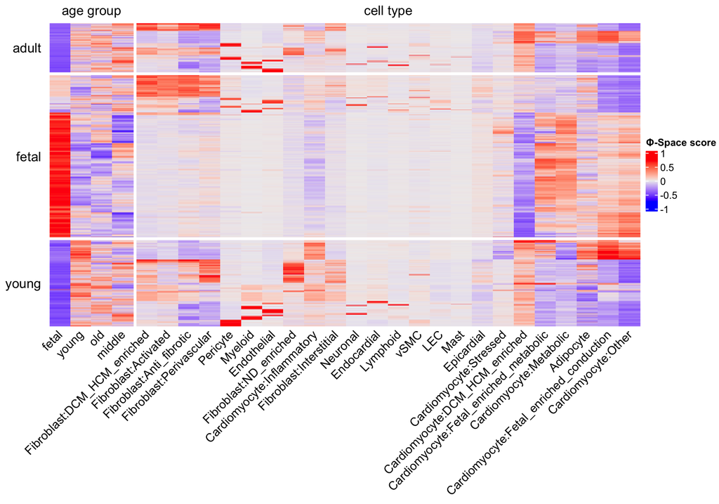

```r
age_levels <- unique(reference$age_group)
split_phenotype <- ifelse(
    colnames(phi_scores) %in% age_levels, "age group", "cell type"
)

ht <- Heatmap(
    phi_scores,
    name             = "Φ-Space score",
    row_split        = query$group,
    column_split     = split_phenotype,
    cluster_row_slices = FALSE,
    show_row_names   = FALSE,
    show_row_dend    = FALSE,
    show_column_dend = FALSE,
    column_names_rot = 45,
    row_title_rot    = 0
)
draw(ht, heatmap_legend_side = "right")
```

### 6.2 PCA biplot of the phenotype space

```r
pc_res <- getPC(phi_scores, ncomp = 5, center = TRUE, scale = FALSE)
round(pc_res$props * 100, 1)
```

```
## [1] 36.7 16.0  8.7  7.9  5.4
```

PC1 and PC2 together explain a large fraction of the variance in phenotype space. We now plot the embedding as a **biplot**: one panel shows the query cells (the `scores`), the other panel shows the reference phenotypes (the `loadings`) in the same 2D basis. Reading the two panels together tells you *why* cells sit where they do — a cell in the positive-PC1 / positive-PC2 quadrant is being pulled there by the phenotypes that load positively on both.

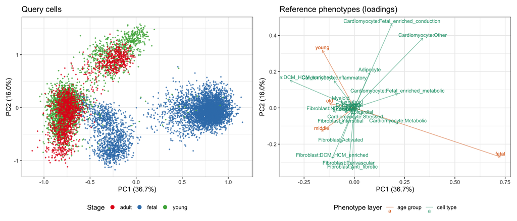

```r
scores_df <- as.data.frame(pc_res$scores[, 1:2])
colnames(scores_df) <- c("PC1", "PC2")
scores_df$group <- query$group

loadings_df <- as.data.frame(pc_res$loadings[, 1:2])
colnames(loadings_df) <- c("PC1", "PC2")
loadings_df$phenotype <- rownames(loadings_df)
loadings_df$layer <- ifelse(
    loadings_df$phenotype %in% unique(reference$age_group),
    "age group", "cell type"
)

pc1_lab <- sprintf("PC1 (%.1f%%)", pc_res$props[1] * 100)
pc2_lab <- sprintf("PC2 (%.1f%%)", pc_res$props[2] * 100)

p_scores <- ggplot(scores_df, aes(PC1, PC2, colour = group)) +
    geom_point(size = 0.6, alpha = 0.7) +
    scale_colour_brewer(palette = "Set1") +
    labs(title = "Query cells", x = pc1_lab, y = pc2_lab, colour = "Stage") +
    theme_bw(base_size = 13) +
    theme(legend.position = "bottom") +
    guides(colour = guide_legend(override.aes = list(size = 3, alpha = 1)))

p_loadings <- ggplot(loadings_df, aes(PC1, PC2, colour = layer)) +
    geom_segment(aes(x = 0, y = 0, xend = PC1, yend = PC2),
                 arrow = arrow(length = unit(0.015, "npc")), alpha = 0.5) +
    geom_text(aes(label = phenotype), size = 3.5, vjust = -0.4) +
    scale_colour_manual(values = c("age group" = "#d95f02", "cell type" = "#1b9e77")) +
    labs(title = "Reference phenotypes (loadings)",
         x = pc1_lab, y = pc2_lab, colour = "Phenotype layer") +
    theme_bw(base_size = 13) +
    theme(legend.position = "bottom")

p_scores + p_loadings
```

This biplot is the single most useful visualisation in Φ-Space. Read it like this:

- **Query cells cluster by stage.** The three stage colours should separate along the PC that is loaded most heavily by `fetal`, `young`, `middle`, `old` — that is the maturation axis we will hand off to slingshot in Module 6.
- **Cell-type phenotypes point to where each lineage lives.** A query cell near a `Cardiomyocyte:*` arrow is a cardiomyocyte; one near a `Fibroblast:*` arrow is a fibroblast. Cells in between the two arrows are transitional / ambiguous and would be assigned inconsistently by a hard classifier.
- **The foetal→adult axis is visible even within cardiomyocytes.** Look at where the `Cardiomyocyte:Fetal_enriched_*` loadings sit relative to the adult-stage CM subclusters — query cardiomyocytes should spread along that direction, which is precisely the trajectory Module 6 will trace.

### 6.3 Query cells coloured by broad cell type

The stage panel tells us *where each donor group lands* in phenotype space, but not *which lineage* each cell belongs to. To see that, we recolour the same query PCA by the broad cell type derived from the fine Φ-Space call (collapsing every `Fibroblast:*` back to `Fibroblast`, every `Cardiomyocyte:*` to `Cardiomyocyte`, etc.). We use `RColorBrewer`’s `Set1` / `Dark2` — pooled to get enough distinct, high-contrast hues for up to ~12 broad lineages without relying on subtle shade differences.

We colour by the *broad* label rather than the fine one because the fine label has 20+ levels — more than any qualitative palette can distinguish cleanly. If we ever need to visualise at the fine resolution, a `facet_wrap(~ broad)` with the fine label inside each panel is much more legible than a single plot with 20+ colours.

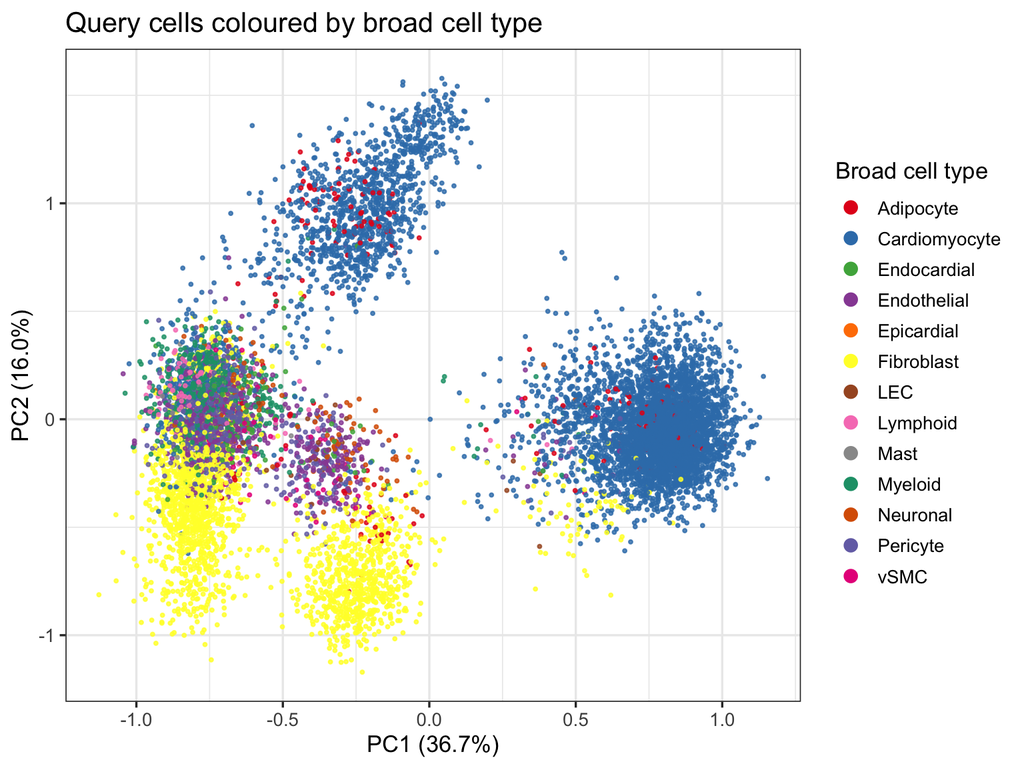

```r
age_levels_biplot <- unique(reference$age_group)
ct_cols_biplot    <- setdiff(colnames(phi_scores), age_levels_biplot)
fine_call         <- getClass(phi_scores[, ct_cols_biplot])
scores_df$broad   <- sub(":.*$", "", fine_call)

n_broad <- length(unique(scores_df$broad))
broad_palette <- c(
    RColorBrewer::brewer.pal(9, "Set1"),
    RColorBrewer::brewer.pal(8, "Dark2")
)[seq_len(n_broad)]

ggplot(scores_df, aes(PC1, PC2, colour = broad)) +
    geom_point(size = 0.6, alpha = 0.8) +
    scale_colour_manual(values = broad_palette) +
    labs(title = "Query cells coloured by broad cell type",
         x = pc1_lab, y = pc2_lab, colour = "Broad cell type") +
    theme_bw(base_size = 13) +
    theme(legend.position = "right") +
    guides(colour = guide_legend(override.aes = list(size = 3, alpha = 1)))
```

Read this panel against the loadings panel above: each broad-cell-type blob should sit on top of (or adjacent to) the loading arrows of its own subtypes. Cardiomyocyte cells should cluster around the `Cardiomyocyte:*` arrows, fibroblasts around the `Fibroblast:*` arrows, and so on.

## 7 Hard vs Soft Classification

Sometimes you genuinely do need a single label per cell — for example, to tabulate cell-type composition per donor. Φ-Space provides `getClass()` for exactly this: it picks the column with the highest score for each cell.

```r
age_cols        <- unique(reference$age_group)
cell_type_cols  <- setdiff(colnames(phi_scores), age_cols)

query$PhiCellType <- getClass(phi_scores[, cell_type_cols])
query$PhiAge      <- getClass(phi_scores[, age_cols])

# Broad label: collapse "CellType:Subtype" back to "CellType".
query$PhiCellTypeBroad <- sub(":.*$", "", query$PhiCellType)

table(query$PhiCellType)
```

```
##
##                               Adipocyte          Cardiomyocyte:DCM_HCM_enriched
##                                     213                                     439
## Cardiomyocyte:Fetal_enriched_conduction  Cardiomyocyte:Fetal_enriched_metabolic
##                                     652                                    1557
##              Cardiomyocyte:Inflammatory                 Cardiomyocyte:Metabolic
##                                     211                                    1116
##                     Cardiomyocyte:Other                  Cardiomyocyte:Stressed
##                                    1375                                      61
##                             Endocardial                             Endothelial
##                                     143                                     557
##                              Epicardial                    Fibroblast:Activated
##                                       3                                     190
##                Fibroblast:Anti_fibrotic             Fibroblast:DCM_HCM_enriched
##                                     373                                     519
##                 Fibroblast:Interstitial                  Fibroblast:ND_enriched
##                                     154                                     537
##                 Fibroblast:Perivascular                                     LEC
##                                     468                                      25
##                                Lymphoid                                    Mast
##                                     100                                      20
##                                 Myeloid                                Neuronal
##                                     519                                     152
##                                Pericyte                                    vSMC
##                                     553                                      63
```

```r
table(query$PhiCellTypeBroad)
```

```
##
##     Adipocyte Cardiomyocyte   Endocardial   Endothelial    Epicardial
##           213          5411           143           557             3
##    Fibroblast           LEC      Lymphoid          Mast       Myeloid
##          2241            25           100            20           519
##      Neuronal      Pericyte          vSMC
##           152           553            63
```

```r
table(query$group, query$PhiAge)
```

```
##
##         fetal middle  old young
##   adult     0    717  561   374
##   fetal  4304    518  391   236
##   young    16    797  716  1370
```

Let’s look at the cardiomyocytes more closely — they are the main interest for Module 6:

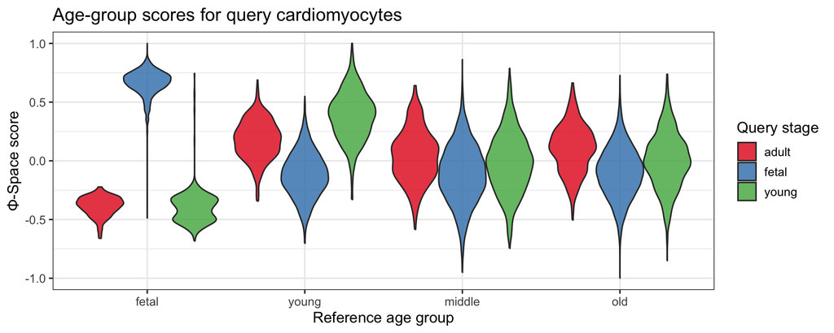

```r
cm_scores <- phi_scores[query$PhiCellTypeBroad == "Cardiomyocyte", age_cols, drop = FALSE]
cm_df <- as.data.frame(cm_scores) %>%
    tibble::rownames_to_column("cell") %>%
    mutate(group = query$group[match(cell, colnames(query))]) %>%
    tidyr::pivot_longer(all_of(age_cols), names_to = "age_phenotype",
                        values_to = "score") %>%
    mutate(age_phenotype = factor(age_phenotype,
                                  levels = c("fetal", "young", "middle", "old")))

ggplot(cm_df, aes(age_phenotype, score, fill = group)) +
    geom_violin(scale = "width", alpha = 0.8) +
    scale_fill_brewer(palette = "Set1") +
    labs(x = "Reference age group", y = "Φ-Space score",
         fill = "Query stage",
         title = "Age-group scores for query cardiomyocytes") +
    theme_bw(base_size = 13)
```

Notice that even within a single query stage there is substantial spread along the age-group axis. A hard classifier hides this spread; the continuous scores are exactly what slingshot will exploit to trace a maturation trajectory.

## 8 Handing Off to Module 6

We save the annotated query object so that Module 6 can pick up where we leave off.

```r
final_cache <- file.path(results_dir, "05_phispace_query.rds")
saveRDS(query, final_cache)
cat("Annotated query at", final_cache, "\n")
```

```
## Annotated query at ../results/05_phispace_query.rds
```

The object now carries:

- `reducedDim(query, "PhiSpace")` — the score matrix (fine cell-type columns + age-group columns).
- `colData(query)$PhiCellType` — discrete *fine* cell-type label (CM / Fibroblast resolved to subtype).
- `colData(query)$PhiCellTypeBroad` — discrete broad cell-type label (CM and Fibroblast subtypes collapsed back).
- `colData(query)$PhiAge` — discrete maturation-stage label.
- all original metadata (`sample`, `group`, `sex`, QC metrics).

In Module 6 we will **subset this object to cardiomyocytes** (using `PhiCellTypeBroad == "Cardiomyocyte"`) and apply **slingshot** to the PhiSpace score matrix. The continuous age-group scores will act as the biological anchor that tells slingshot which end of the trajectory is foetal and which end is adult.

## 9 Summary

- Φ-Space replaces a hard cell-type label with a continuous score per reference phenotype per cell — a natural fit for a dataset that spans a developmental gradient.
- The workflow is four steps: match normalisation (we used scran normalisation on both reference and query), keep common genes, run `PhiSpace()` with one or more phenotype layers, inspect the scores.
- Continuous scores can always be collapsed to a discrete label with `getClass()`, but the inverse is not possible — preserve the scores for any downstream analysis that benefits from soft assignments (trajectory inference, co-phenotype analysis, gradient visualisation).
- The phenotype-space embedding we saved is the input to Module 6 (pseudotime) and Module 7 (gene regulatory networks).